# Solutions 8: Estimation with Multiple Linear Regression

Author

Affiliation

Adam Spiegler

University of Colorado Denver

## Additional Reading

# Loading Required Packages

```r
library(faraway)  # to access Galapagos
library(tidyverse)
library(microbenchmark)  # for comparing computation speeds
```

# Multiple Linear Regression Models

A **multiple linear regression** model is a linear regression model with more than one predictor $X_i$ and a single response variable $Y$. In general, we include an intercept term as a predictor, so if there are $p$ predictor variables, our model has $p+1$ regression coefficients. The most common multiple linear regression model is

$$Y = \beta_0 + \beta_1 X_1 + \beta_2 X_2 + \ldots + \beta_p X_p + \epsilon .$$

The model does not need to be linear in the predictor variables. For example, we can construct a polynomial with one predictor using multiple linear regression:

$$Y = \beta_0 + \beta_1 X + \beta_2 X^2 + \ldots + \beta_p X^p + \epsilon .$$

We can transform some predictor variables and the response in our model. For example,

$$\log{(Y)} = \beta_0 + \beta_1 X_1 + \beta_2 \log{(X_2)} + \beta_3 X_3^2 + \epsilon .$$
Combining several predictors into a single term in the model. Products of regressors are called **interactions**. They are often included to allow for joint effects of predictors.

$$Y = \beta_0 + \beta_1 X_1 + \beta_2 X_2 + \beta_3 X_1X_2 + \epsilon .$$

## Random Vectors

The notation $Y$ and $\epsilon$ represent **random vectors**. Suppose we have a sample on $n$ observations. Then for each set of observed values, we have two $n\times1$ vectors of random variables:

$$\mathbf{y} = \left[ \begin{array}{c} Y_1 \\ Y_2 \\ \vdots \\ Y_n \end{array} \right]
\qquad \text{and} \qquad
\boldsymbol{\epsilon} = \left[ \begin{array}{c} \epsilon_1 \\ \epsilon_2 \\ \vdots \\ \epsilon_n \end{array} \right]$$

We use lower-case $\mathbf{y}$ since bold lower-case letters are typically used to denote vectors in mathematics while bold upper-case letters typically represent matrices. See Appendix for information about finding expected value, variance, and covariance of random vectors.

**Note**

We typically will not denote random vectors using bold font and instead will use regular font $Y$ and $\epsilon$ to denote random vectors and $Y_i$ and $\epsilon_i$ to denote the $i^{\text{th}}$ entries in each vector. We also may often express the vectors as the transpose of $1 \times n$ vectors since that saves vertical space on the page.

$$y = \left[ Y_1 , Y_2 ,\ldots , Y_n \right]^T
\ \ \text{ and } \ \
\epsilon = \left[ \epsilon_1 \\ \epsilon_2 , \ldots, \epsilon_n \right]^T$$

# The Ingredients of Multiple Linear Regression

We now consider the context where we want to estimate the parameters of a linear model with 1 or more regressors, i.e., when

$$Y=\beta_0 + \beta_1 X_1 + \cdots + \beta_{p-1} X_{p-1} + \epsilon.$$

We define the following notation before expressing the model as an equivalent matrix equation.

- $\mathbf{y} = \lbrack Y_1, Y_2, \ldots, Y_n \rbrack^T$ denotes the column vector containing the $n$ response variables.
  - It is am $n \times 1$ random vector whose entries are each a random variable $Y_i$.
  - For each observation, we can observe a value for the response variable $y_i$, but it varies.
  - For each observation, we can compute the fitted value $\hat{y}_i$ to predict the value of $Y_i$.
  - We denote $\mathbf{\hat{y}}$ the $n \times 1$ vector of fitted values which we can compute and observe.
- $\mathbf{X}$ denotes the matrix containing a column of 1’s (for the intercept) followed by columns of values corresponding to each regressor in our model.
  - The entries in column 2 ($x_{11}, x_{21}, \ldots , x_{n1}$) correspond to the values of regressor variable $X_1$. $x_{i1}$ is the value of $X_1$ for the $i^{\text{th}}$ observation.
  - $\mathbf{X}$ consists fixed and observable values.

$$\mathbf{X} = \begin{bmatrix}
1 & x_{11} & x_{12} & \cdots & x_{1,p-1} \\
1 & x_{21} & x_{22} & \cdots & x_{2,p-1} \\
\vdots & \vdots & \vdots & \vdots & \vdots \\
1 & x_{n1} & x_{n2} & \cdots & x_{n,p-1}
\end{bmatrix}.$$

- $\boldsymbol{\beta} = [\beta_0, \beta_1, \ldots, \beta_{p-1}]^T$ denotes the $p \times 1$ column vector containing the $p$ regression coefficients.
  - The $\boldsymbol{\beta}$ is parameter whose value is fixed (not random) but unknown (not observable).
  - We can use different methods to find estimators $\boldsymbol{\hat{\beta}} = [\hat{\beta}_0, \hat{\beta}_1, \ldots, \hat{\beta}_{p-1}]^T$.
  - We will use OLS estimates computed by minimizing the RSS.
- $\boldsymbol{\epsilon} = [\epsilon_1, \epsilon_2, \ldots, \epsilon_n]^T$ denotes the $n \times 1$ random vector containing random variables corresponding to the $n$ errors.
  - Recall each $\epsilon_i$ is a random variable.
  - We can estimate the error using an $n \times 1$ vector of observed residuals, $\boldsymbol{\hat{\epsilon}}$.

Then the system of equations defining the linear model can be written as a matrix equation :

$$\large{ \mathbf{y} = \mathbf{X}\boldsymbol{\beta} + \boldsymbol{\epsilon}. }$$

**Note**

Each $Y_i$ is a random variable since with different samples, we may observe different values of $Y_i$ given the same value(s) for the predictor(s). In general, if the object’s value varies due to randomness in sampling, it is a random variable.

## Question 1

Summarize this information in the table below for the objects previously discussed using the various notations introduced.

### Solution to Question 1

| Notation | Description | Observable | Random |
| --- | --- | --- | --- |
| $Y$ | response variable | Yes | Yes |
| $Y_i$ | response value for the $i^{\text{th}}$ observation (we observe one value out of the many possible values) | Yes | Yes |
| $\mathbf{y}$ | the $n\times 1$ column vector of response values | Yes | Yes |
| $X_j$ | the $j$th predictor variable | Yes | No |
| $x_{i,j}$ | the value of the $j$th predictor variable for the $i$th observation | Yes | No |
| $\mathbf{X}$ | the $n\times p$ matrix of predictor values | Yes | No |
| $\beta_j$ | the regression coefficient associated with the $j$th predictor variable | No | No |
| $\boldsymbol{\beta}$ | the $p\times 1$ column vector of regression coefficients | No | No |
| $\boldsymbol{\epsilon}$ | the $n\times 1$ column vector of errors | No | Yes |
| $\epsilon_i$ | the error associated with observation $i$ | No | Yes |
| $\hat{\beta}_j$ | the estimator for $\beta_j$ | Yes | Yes |
| $\boldsymbol{\hat{\beta}}$ | the $p\times 1$ column vector of estimates for the regression coefficients | Yes | Yes |
| $\hat{\epsilon}_i$ | the residual associated with the $i^{\text{th}}$ observation | Yes | Yes |

# OLS Estimators

The least squares estimator of $\boldsymbol{\beta}$ , denoted $\boldsymbol{\hat{\beta}}$, minimizes

$$\text{RSS}(\boldsymbol{\hat{\beta}})= \sum \hat{\epsilon}_i^2 = \boldsymbol{\hat{\epsilon}}^T \boldsymbol{\hat{\epsilon}} = (\mathbf{y} -\mathbf{X}\boldsymbol{\hat{\beta}})^T( \mathbf{y} -\mathbf{X}\boldsymbol{\hat{\beta}}) .$$

How do we find the value of $\boldsymbol{\hat{\beta}}$ that minimizes RSS?

- With two predictors, we want to find the plane that minimizes the sum of squared distances (projections) of each point to the plane (regression line).
- Same idea in higher dimensions with more predictors.

[interactive chart not shown]

## Matrix Derivatives

Now lets look at the derivative of a scalar function with respect to a vector.

Let $f(\mathbf{x})$ be a function of a $p\times 1$ column vector $\mathbf{x}=[x_1, x_2, \ldots, x_p]^T$. The derivative of $f(\mathbf{x})$ with respect to $\mathbf{x}$ is denoted $\frac{\partial f(\mathbf{x})}{\partial \mathbf{x}}$ and

$$\frac{\partial f(\mathbf{x})}{\partial \mathbf{x}} = \begin{bmatrix}
\frac{\partial f(\mathbf{x})}{\partial x_1}\\
\frac{\partial f(\mathbf{x})}{\partial x_2}\\
\vdots \\
\frac{\partial f(\mathbf{x})}{\partial x_p}
\end{bmatrix}.$$

Let

$$\mathbf{x} = \begin{bmatrix} x_1 \\ x_2\\ x_3 \end{bmatrix}, \quad
\mathbf{a} = \begin{bmatrix} a_1 \\ a_2\\ a_3 \end{bmatrix}, \quad \text{and }
\mathbf{A} = \begin{bmatrix} a_{11} & a_{12} \\
a_{21} & a_{22} \\
a_{31} & a_{32} \end{bmatrix},$$

and consider the examples below.

**Example 1**

$f(\mathbf{x}) = \mathbf{x}^T \mathbf{a} = a_1x_1 + a_2x_2 + a_3x_3$ has the following derivative:

$$\frac{d}{d \mathbf{x}} \left( \mathbf{x}^T \mathbf{a} \right) = \begin{bmatrix}
\frac{d}{dx_1} (a_1x_1 + a_2x_2 + a_3b_3) \\
\frac{d}{dx_2} (a_1x_1 + a_2x_2 + a_3b_3) \\
\frac{d}{dx_3} (a_1x_1 + a_2x_2 + a_3b_3) \end{bmatrix} = \begin{bmatrix}
a_1 \\ a_2 \\ a_3
\end{bmatrix} = \mathbf{a}$$

More generally (for any dimension) $\frac{d}{d \mathbf{x}} \left( \mathbf{x}^T \mathbf{a} \right) = \mathbf{a}$.

**Example 2**

$f(\mathbf{x}) = \mathbf{x}^T \mathbf{x} = x_1^2 + x_2^2 + x_3^2$ has the following derivative:

$$\frac{d}{d \mathbf{x}} \left( \mathbf{x}^T \mathbf{x} \right) = \begin{bmatrix}
\frac{d}{dx_1} (x_1^2 + x_2^2 + x_3^2) \\
\frac{d}{dx_2} (x_1^2 + x_2^2 + x_3^2) \\
\frac{d}{dx_3} (x_1^2 + x_2^2 + x_3^2) \end{bmatrix} = \begin{bmatrix}
2x_1 \\ 2x_2 \\ 2x_3
\end{bmatrix} = 2 \mathbf{x}$$

More generally (for any dimension) $\frac{d}{d \mathbf{x}} \left( \mathbf{x}^T \mathbf{x} \right) = 2\mathbf{x}$.

**Example 3**

Let $\mathbf{a}_1$ and $\mathbf{a}_2$ denote the column vectors of $3 \times 2$ matrix $\mathbf{A}$ defined above. Consider the function

$$f(\mathbf{x}) = \mathbf{x}^T \mathbf{A} = \begin{bmatrix} x_1 & x_2 & x_3 \end{bmatrix} \begin{bmatrix} a_{11} & a_{12} \\
a_{21} & a_{22} \\
a_{31} & a_{32} \end{bmatrix} = \begin{bmatrix} \mathbf{x}^T \mathbf{a}_1 & \mathbf{x}^T \mathbf{a}_2 \end{bmatrix} .$$

$$\begin{align}
\frac{d}{d \mathbf{x}} \left( \mathbf{x}^T \mathbf{A} \right) &=
\frac{d}{d \mathbf{x}} \left( \begin{bmatrix} \mathbf{x}^T \mathbf{a}_1 & \mathbf{x}^T \mathbf{a}_2 \end{bmatrix} \right) \\
&=\begin{bmatrix} \frac{d}{d \mathbf{x}} \left( \mathbf{x}^T \mathbf{a}_1 \right) & \frac{d}{d \mathbf{x}} \left( \mathbf{x}^T \mathbf{a}_2 \right) \end{bmatrix} \\
&= \begin{bmatrix} \mathbf{a}_1 & \mathbf{a}_2 \end{bmatrix} \\
&= \mathbf{A}
\end{align}$$

We can similarly show, for appropriately sized matrix $\mathbf{A}$,

$$\frac{d}{d \mathbf{x}} \left( \mathbf{A} \mathbf{x} \right) = \mathbf{A}$$

## Question 2

- Expand the product $(\mathbf{y} -\mathbf{X}\boldsymbol{\hat{\beta}})^T( \mathbf{y} -\mathbf{X}\boldsymbol{\hat{\beta}})$.
- Then take the derivative with respect to $\boldsymbol{\hat{\beta}}$ and set equal to $\mathbf{0}$.
- Solve for $\boldsymbol{\hat{\beta}}$.

### Solution to Question 2

#### Expand the product

$$\begin{align}
(\mathbf{y} -\mathbf{X}\boldsymbol{\hat{\beta}})^T( \mathbf{y} -\mathbf{X}\boldsymbol{\hat{\beta}}) &=
\big( \mathbf{y}^T - (\mathbf{X}\boldsymbol{\hat{\beta}})^T \big) ( \mathbf{y} -\mathbf{X}\boldsymbol{\hat{\beta}}) \\
&=
\big( \mathbf{y}^T - \boldsymbol{\hat{\beta}}^T \mathbf{X}^T \big) ( \mathbf{y} -\mathbf{X}\boldsymbol{\hat{\beta}}) \\
&= \mathbf{y}^T \mathbf{y} - \mathbf{y}^T \mathbf{X}\boldsymbol{\hat{\beta}} - \boldsymbol{\hat{\beta}}^T \mathbf{X}^T \mathbf{y} + \boldsymbol{\hat{\beta}}^T \mathbf{X}^T \mathbf{X}\boldsymbol{\hat{\beta}} \\
&= \mathbf{y}^T \mathbf{y} - \mathbf{y}^T \mathbf{X}\boldsymbol{\hat{\beta}} - (\mathbf{X} \boldsymbol{\hat{\beta}})^T \mathbf{y} + (\mathbf{X}\boldsymbol{\hat{\beta}} )^T (\mathbf{X}\boldsymbol{\hat{\beta}} ) \\
&= \mathbf{y}^T \mathbf{y} - \mathbf{y}^T \mathbf{X}\boldsymbol{\hat{\beta}} - \mathbf{y}^T\mathbf{X}\boldsymbol{\hat{\beta}} + (\mathbf{X}\boldsymbol{\hat{\beta}} )^T (\mathbf{X}\boldsymbol{\hat{\beta}} )\\
&= \mathbf{y}^T \mathbf{y} - 2\mathbf{y}^T \mathbf{X}\boldsymbol{\hat{\beta}} + (\mathbf{X}\boldsymbol{\hat{\beta}} )^T (\mathbf{X}\boldsymbol{\hat{\beta}} )
\end{align}$$
.

**Caution**

In the work above (and below), note $(\mathbf{X} \boldsymbol{\hat{\beta}})^T \mathbf{y}$ results in a scalar. Thus, taking the transpose again would result in the same scalar.

$$(\mathbf{X} \boldsymbol{\hat{\beta}})^T \mathbf{y} = \left( (\mathbf{X} \boldsymbol{\hat{\beta}})^T \mathbf{y} \right)^T = \mathbf{y}^T (\mathbf{X} \boldsymbol{\hat{\beta}})$$

It is generally NOT true that $\mathbf{A}^T \mathbf{B} = \mathbf{B}^T \mathbf{A}$ when working with appropriately sized matrices.

#### Take the derivative with respect to $\boldsymbol{\hat{\beta}}$

$$\begin{align}
\frac{d}{d \boldsymbol{\hat{\beta}}} \left( \mathbf{y}^T \mathbf{y} - 2\mathbf{y}^T \mathbf{X}\boldsymbol{\hat{\beta}} + (\mathbf{X}\boldsymbol{\hat{\beta}} )^T (\mathbf{X}\boldsymbol{\hat{\beta}} ) \right) &=
\frac{d}{d \boldsymbol{\hat{\beta}}} \left( \mathbf{y}^T \mathbf{y} \right) - 2 \frac{d}{d \boldsymbol{\hat{\beta}}} \left( \mathbf{y}^T \mathbf{X}\boldsymbol{\hat{\beta}} \right) + \frac{d}{d \boldsymbol{\hat{\beta}}} \left( (\mathbf{X}\boldsymbol{\hat{\beta}} )^T (\mathbf{X}\boldsymbol{\hat{\beta}} ) \right) \\
&= 0 -2 \mathbf{y}^T \mathbf{X} + \frac{d}{d \boldsymbol{\hat{\beta}}} \left[ (\mathbf{X}\boldsymbol{\hat{\beta}} )^T \right] \left( \mathbf{X}\boldsymbol{\hat{\beta}} \right) + \left( \mathbf{X}\boldsymbol{\hat{\beta}} \right)^T \frac{d}{d \boldsymbol{\hat{\beta}}} \left[ (\mathbf{X}\boldsymbol{\hat{\beta}} ) \right] \\
&= -2 \mathbf{y}^T \mathbf{X} + \bigg( \frac{d}{d \boldsymbol{\hat{\beta}}} \left[ \mathbf{X}\boldsymbol{\hat{\beta}} \right] \bigg)^T \left( \mathbf{X}\boldsymbol{\hat{\beta}} \right) + \left( \mathbf{X}\boldsymbol{\hat{\beta}} \right)^T \frac{d}{d \boldsymbol{\hat{\beta}}} \left[ (\mathbf{X}\boldsymbol{\hat{\beta}} ) \right] \\
&= -2 \mathbf{y}^T \mathbf{X} + (\mathbf{X})^T \left( \mathbf{X}\boldsymbol{\hat{\beta}} \right) + \left( \mathbf{X}\boldsymbol{\hat{\beta}} \right)^T (\mathbf{X}) \\
&= -2 \mathbf{y}^T \mathbf{X} + 2 \mathbf{X}^T \mathbf{X}\boldsymbol{\hat{\beta}}
\end{align}$$
.

**Caution**

Again we note a similar special case:

- $\mathbf{X}^T\mathbf{X} \boldsymbol{\hat{\beta}}$ results in a column vector with the same dimensions as $\boldsymbol{\hat{\beta}}$.
- $\boldsymbol{\hat{\beta}}^T \mathbf{X}^T \mathbf{X}$ results in the same vector as the product above, expressed in the form of a row vector.
- In order to add the vectors, we treat all as column vectors, and thus

$$\mathbf{X}^T \mathbf{X}\boldsymbol{\hat{\beta}}= \boldsymbol{\hat{\beta}}^T \mathbf{X}^T \mathbf{X} .$$
Want to be clear (again) that it is generally NOT true that $\mathbf{A}^T \mathbf{B} = \mathbf{B}^T \mathbf{A}$ when working with appropriately sized matrices.

#### When is derivative equal to zero?

To find critical points where the RSS is minimized, we set the derivative equal to $\mathbf{0}$ (the $n \times 1$ zero vector) and solve for $\boldsymbol{\hat{\beta}}$.

We have

$$-2 \mathbf{y}^T \mathbf{X} + 2 \mathbf{X}^T \mathbf{X}\boldsymbol{\hat{\beta}} = \mathbf{0}$$
which gives

$$\mathbf{X}^T \mathbf{X}\boldsymbol{\hat{\beta}} = \mathbf{y}^T \mathbf{X}$$

or

$$\mathbf{X}^T \mathbf{X}\boldsymbol{\hat{\beta}} = \mathbf{X}^T \mathbf{y}.$$

**Note**

The resulting system above is called the normal equations.

Multiplying both sides (on the left) by $(X^TX)^{-1}$ (if it exists), gives the OLS estimator

$$\large{ \boldsymbol{\hat{\beta}} = \left( \mathbf{X}^T \mathbf{X} \right)^{-1} \mathbf{X}^T \mathbf{y} }$$
where $\mathbf{X}$ is the matrix of observed values of the predictor variables and $\mathbf{y}$ is the vector of observed values of the response variable. Since we know all of these values, we can compute $\boldsymbol{\hat{\beta}}$.

## The Hat Matrix

The fitted values $\mathbf{\hat{y}} = [ \hat{y}_1, \hat{y}_2, \ldots , \hat{y}_n ]$ may be expressed as

$$\mathbf{\hat{y}} = \mathbf{X} \boldsymbol{\hat{\beta}} = \mathbf{X} \left( \mathbf{X}^T \mathbf{X} \right)^{-1} \mathbf{X}^T \mathbf{y}$$

- The matrix $\mathbf{H} = \mathbf{X} \left( \mathbf{X}^T \mathbf{X} \right)^{-1} \mathbf{X}^T$ is called the **hat matrix** or **projection matrix**
- $\mathbf{H} \mathbf{y}$ is the orthogonal projection of each observed point onto the space spanned by $\mathbf{X}$.
- $\mathbf{H} \mathbf{y}$ is a useful theoretical matrix, but it is often not computed since it is an $n \times n$ matrix, and typically our sample size $n$ is very large.

## Question 3

Show the residual sum of squares, RSS, may be written as

$$\text{RSS} = \sum \hat{\epsilon}_i^2 = \boldsymbol{\hat{\epsilon}}^T \boldsymbol{\hat{\epsilon}} = \mathbf{y}^T (\mathbf{I}_n - \mathbf{H}) \mathbf{y}.$$

**Note**

I should have asked Question 4 before asking Question 3. You can skip down to Question 4 and then come back here!

### Solution to Question 3

We have

$$\mathbf{\hat{y}} = \mathbf{X} \boldsymbol{\hat{\beta}} = \mathbf{X}(\mathbf{X}^T\mathbf{X})\mathbf{X}^T \mathbf{y} = \mathbf{H} \mathbf{y}$$

$$\begin{align}
(\mathbf{y} - \mathbf{\hat{y}})^T( \mathbf{y} -\mathbf{\hat{y}}) &= (\mathbf{y} - \mathbf{H} \mathbf{y})^T(\mathbf{y} - \mathbf{H} \mathbf{y})\\
&= \big( (\mathbf{I}_n - \mathbf{H}) \mathbf{y} \big)^T \big( (\mathbf{I}_n - \mathbf{H}) \mathbf{y} \big)\\
&= \big( \mathbf{y}^T(\mathbf{I}_n - \mathbf{H})^T \big) \big( (\mathbf{I}_n - \mathbf{H}) \mathbf{y} \big)\\
&=\mathbf{y}^T (\mathbf{I}_n - \mathbf{H})^T (\mathbf{I}_n - \mathbf{H}) \mathbf{y}
\end{align}$$

See Question 4 below to use the fact that $(\mathbf{I}_n - \mathbf{H})$ is symmetric and idempotent, which means

$$(\mathbf{I}_n - \mathbf{H})^T(\mathbf{I}_n - \mathbf{H}) = (\mathbf{I}_n - \mathbf{H})^2 = (\mathbf{I}_n - \mathbf{H}).$$

By result in Question 4, we therefore have

$$\begin{align}
\boldsymbol{\hat{\epsilon}}^T \boldsymbol{\hat{\epsilon}} &= (\mathbf{y} - \mathbf{\hat{y}})^T( \mathbf{y} -\mathbf{\hat{y}})\\
&= \mathbf{y}^T (\mathbf{I}_n - \mathbf{H})^T (\mathbf{I}_n - \mathbf{H}) \mathbf{y} \\
&= \mathbf{y}^T (\mathbf{I}_n - \mathbf{H}) \mathbf{y}
\end{align}$$

# Fitted Values and Residuals

- The **fitted model** is given by

$$\hat{Y} = \widehat{E} ( Y \ | \ X) = \hat{\beta}_0 + \hat{\beta}_1 X_1 + \hat{\beta}_2 X_2 + \ldots + \hat{\beta}_{p-1} X_{p-1} .$$

- The **$i^{\text{th}}$** fitted value is therefore given by

$$\hat{y}_i = \widehat{E} ( Y \ | \ X_1 = x_{i1} , \ldots , X_{p-1} = x_{i, p-1}) = \hat{\beta}_0 + \hat{\beta}_1 x_{i1} + \hat{\beta}_2 x_{i2} + \ldots + \hat{\beta}_{p-1} x_{i, p-1} .$$

- The residuals, $\boldsymbol{\hat{\epsilon}} = (\hat{\epsilon}_1, \hat{\epsilon}_2, \ldots , \hat{\epsilon}_n)^T$ are given by

$$\boldsymbol{\hat{\epsilon}}= \mathbf{y} - \hat{\mathbf{y}} = \mathbf{y} - \mathbf{Hy} = (\mathbf{I}_n - \mathbf{H}) \mathbf{y}.$$

- The residual of individual observation $i$ is

$$\hat{\epsilon}_i = y_i - \hat{y}_i = y_i - (\hat{\beta}_0 + \hat{\beta}_1 x_{i1} + \hat{\beta}_2 x_{i2} + \ldots + \hat{\beta}_{p-1} x_{i, p-1}) .$$

## Question 4

Show that $\mathbf{I}_n - \mathbf{H}$ is symmetric and idempotent.

**Tip**

A square matrix $\mathbf{A}$ is idempotent if $A^2 = A$. Show $(\mathbf{I}_n - \mathbf{H})^2=\mathbf{I}_n - \mathbf{H}$.

### Solution to Question 4

#### Claim 1: $\mathbf{H}$ is Symmetric

$$\begin{align}
\mathbf{H}^T &= \bigg( \mathbf{X} (\mathbf{X}^T \mathbf{X})^{-1}\mathbf{X}^T \bigg)^T\\
&= \left( \mathbf{X}^T \right)^T \bigg( (\mathbf{X}^T \mathbf{X})^{-1} \bigg)^T \mathbf{X}^T\\
&= \mathbf{X} \bigg( (\mathbf{X}^T \mathbf{X})^{-1} \bigg)^T \mathbf{X}^T\\
&= \mathbf{X} \bigg( (\mathbf{X}^T \mathbf{X})^T \bigg)^{-1} \mathbf{X}^T \\
&= \mathbf{X} \bigg( \mathbf{X}^T \mathbf{X} \bigg)^{-1} \mathbf{X}^T \\
&= \mathbf{H}
\end{align}$$

#### Claim 2: $\mathbf{I}_n - \mathbf{H}$ is Symmetric

$$(\mathbf{I}_n - \mathbf{H})^T = \mathbf{I}_n^T - \mathbf{H}^T = \mathbf{I}_n - \mathbf{H}.$$

#### Claim 3: $\mathbf{H}$ is Idempotent

You’ll prove that!

#### Claim 4: $\mathbf{I}_n - \mathbf{H}$ is Idempotent

$$\begin{align}
(\mathbf{I}_n - \mathbf{H})^2 &= (\mathbf{I}_n - \mathbf{H})^T (\mathbf{I}_n - \mathbf{H})\\
&=(\mathbf{I}_n - \mathbf{H}^T) (\mathbf{I}_n - \mathbf{H}) \\
&=\mathbf{I}_n - \mathbf{H} - \mathbf{H}^T + \mathbf{H}^T \mathbf{H}\\
&= \mathbf{I}_n - \mathbf{H} - \mathbf{H} + \mathbf{H}^2 \qquad \text{by claim 1}\\
&= \mathbf{I}_n - \mathbf{H} - \mathbf{H} + \mathbf{H} \qquad \text{by claim 3}\\
&= \mathbf{I}_n - \mathbf{H}
\end{align}$$

Since $(\mathbf{I}_n - \mathbf{H})^2 = (\mathbf{I}_n - \mathbf{H})$, we have proven $\mathbf{I}_n - \mathbf{H}$ is idempotent.

# Properties of the OLS Estimator

- The ordinary least squares estimator $\boldsymbol{\hat{\beta}}$ is an **unbiased estimator** for $\boldsymbol{\beta}$.
- The OLS estimator $\boldsymbol{\hat{\beta}}$ is also the **most efficient** estimator. It has the minimum variance among all unbiased estimators when $\text{Var} (\boldsymbol{\epsilon}) = \sigma^2 \mathbf{I}_n$.
- The OLS estimator for $\text{Var} (\boldsymbol{\epsilon})$ is given by

$$\hat{\boldsymbol\sigma}^2 = \frac{ \boldsymbol{\hat{\epsilon}}^T \boldsymbol{\hat{\epsilon}} }{n-p} = \frac{ \text{RSS} }{n-p} .$$

## Question 5

Show that $\boldsymbol{\hat{\beta}}$ is an unbiased estimator for $\boldsymbol{\beta}$.

### Solution to Question 5

We want to show $E( \boldsymbol{\hat{\beta}}) = \boldsymbol{\beta}$. We have

$$\begin{align}
E( \boldsymbol{\hat{\beta}}) &= E \left( (\mathbf{X}^T \mathbf{X})^{-1} \mathbf{X}^T \mathbf{y} \right)\\
&= (\mathbf{X}^T \mathbf{X})^{-1} \mathbf{X}^T \ E( \mathbf{y}) \\
&= (\mathbf{X}^T \mathbf{X})^{-1} \mathbf{X}^T E \left( \mathbf{X} \boldsymbol{\beta} + \boldsymbol{\epsilon} \right) \\
&= (\mathbf{X}^T \mathbf{X})^{-1} \mathbf{X}^T \left( \mathbf{X} \boldsymbol{\beta} + E (\boldsymbol{\epsilon}) \right) \\
&= (\mathbf{X}^T \mathbf{X})^{-1} \mathbf{X}^T \mathbf{X} \boldsymbol{\beta} \\
&= \boldsymbol{\beta}
\end{align}$$

Yay! $\boldsymbol{\hat{\beta}}$ is an unbiased estimator for $\boldsymbol{\beta}$.

# Revisiting Simple Linear Regression

Suppose we have a simple linear regression model $\hat{Y} = \hat{\beta}_0 + \hat{\beta}_1 X$. We have a data set of $n$ observations giving a system of linear equations given by the matrix equation

$$\begin{bmatrix} y_1 \\ y_2 \\ \vdots \\ y_n \end{bmatrix} = \begin{bmatrix} 1 & x_{11} \\ 1 & x_{12} \\ \vdots & \vdots \\ 1 & x_{1n} \end{bmatrix} \begin{bmatrix} \hat{\beta}_0 \\ \hat{\beta}_1 \\ \vdots \\ \hat{\beta}_n \end{bmatrix}.$$

## Question 6

Using the matrix above, derive OLS estimates for $\hat{\beta}_0$ and $\hat{\beta}_1$ using the result that $\boldsymbol{\hat{\beta}} = (X^TX)^{-1}(X^T) \mathbf{y}$.

### Solution to Question 6

**A messy solution**

$$\mathbf{X}^T \mathbf{X} = \begin{bmatrix} 1 & 1 & \ldots & 1 \\
x_{11} & x_{12} & \ldots & x_{1n}\\ \end{bmatrix}
\begin{bmatrix} y_1 \\ y_2 \\ \vdots \\ y_n \end{bmatrix} =
\begin{bmatrix} n & \sum_{i=1}^n x_{i1} \\
\sum_{i=1}^n x_{i1} & \sum_{i=1}^n x_{i1}^2\end{bmatrix}$$

To find $(\mathbf{X}^T \mathbf{X})^{-1}$ we use the fact that $\text{det} (\mathbf{X}^T \mathbf{X}) = n \sum_{i=1}^n x_{i1}^2 - \left( \sum_{i=1}^n x_{i1} \right)^2$. Thus,

$$(\mathbf{X}^T \mathbf{X})^{-1} = \frac{1}{ n \sum_{i=1}^n x_{i1}^2 - \left( \sum_{i=1}^n x_{i1} \right)^2} \begin{bmatrix} \sum_{i=1}^n x_{i1}^2 & -\sum_{i=1}^n x_{i1} \\
-\sum_{i=1}^n x_{i1} & n \end{bmatrix}$$

We also have

$$\mathbf{X}^T \mathbf{y} = \begin{bmatrix} 1 & 1 & \ldots & 1 \\
x_{11} & x_{12} & \ldots & x_{1n} \end{bmatrix} \begin{bmatrix} y_1 \\ y_2 \\ \vdots y_n \end{bmatrix} = \begin{bmatrix} \sum_{i=1}^n y_i \\ \sum_{i=1}^n (x_{i1} y_i) \end{bmatrix}.$$

Finally, we have

$$\begin{align}
\begin{bmatrix} \hat{\beta}_0 \\ \hat{\beta}_1 \end{bmatrix} &=
(\mathbf{X}^T \mathbf{X})^{-1} \mathbf{X}^T \mathbf{y} \\
&= \frac{1}{ n \sum_{i=1}^n x_{i1}^2 - \left( \sum_{i=1}^n x_{i1} \right)^2} \begin{bmatrix} \sum_{i=1}^n x_{i1}^2 & -\sum_{i=1}^n x_{i1} \\
-\sum_{i=1}^n x_{i1} & n \end{bmatrix}
\begin{bmatrix} \sum_{i=1}^n y_i \\ \sum_{i=1}^n (x_{i1} y_i) \end{bmatrix} \\
\\
&= \frac{1}{ n \sum x_{i1}^2 - \left( \sum x_{i1} \right)^2}
\begin{bmatrix} \sum x_{i1}^2 \sum y_i -\bigg( \sum x_{i1} \bigg) \bigg( \sum (x_{i1} y_i) \bigg) \\
- \bigg( \sum x_{i1} \bigg) \bigg(\sum y_i \bigg) +
n \sum \big( x_{i1} y_i \big)\end{bmatrix}
\end{align}$$

## Revisiting World Development Indicators

The data set stored in `country.csv` contains information about [World Development Indicators (WDI)](https://datatopics.worldbank.org/world-development-indicators/) for many countries. We explored this data set in the previous model. Run the code cell below to load the data.

```r
country <- read_csv("https://raw.githubusercontent.com/aspiegler/Applied-Regression/main/Data/country.csv")
head(country)
```

```
# A tibble: 6 × 6
  country             life_exp gdp_per_cap lit_rate fertility land_area
  <chr>                  <dbl>       <dbl>    <dbl>     <dbl>     <dbl>
1 Afghanistan             66.0       2202.     37        4.84    652230
2 Albania                 79.6      23488.     98.5      1.35     27400
3 Algeria                 76.3      17553.     81.4      2.77   2381741
4 Angola                  64.6       8348.     72.4      5.12   1246700
5 Antigua and Barbuda     77.6      33602.     99        1.58       440
6 Argentina               77.4      30176.     97        1.5    2736690
```

- `life_exp`: Life expectancy at birth (in years).
- `gdp_per_cap`: GDP per capita (in dollars).
- `lit_rate`: Adult literacy rate (in %) is indicator.
- `fertility`: Fertility rate (total births per woman) is indicator.
- `land_area`: Land area (in square km) is indicator.

### Life Expectancy and Fertility Rate

In the [previous module](https://aspiegler.github.io/Applied-Regression/07-MLR-Part1.html) we constructed a simple linear regression model for the response variable `life_exp` in terms of the predictor `fertility` based on the data in `country`.

```r
(life_lmod <- lm(life_exp ~ fertility, data = country))
```

```
Call:
lm(formula = life_exp ~ fertility, data = country)

Coefficients:
(Intercept)    fertility
     83.681       -4.428
```

See Appendix A for a glossary of useful linear algebra and `lm()` functions in R.

```r
# create model matrix X
x <- model.matrix(~ fertility, data = country)
head(x)
```

```
  (Intercept) fertility
1           1     4.840
2           1     1.348
3           1     2.766
4           1     5.124
5           1     1.578
6           1     1.500
```

```r
# vector of observed values of response
y <- country$life_exp
```

```r
# compute hat matrix, 162 by 162 matrix
h <- x %*% solve(t(x) %*% x) %*% t(x)
```

Recall we have OLS estimator

$$\boldsymbol{\hat{\beta}} = \left( \mathbf{X}^T \mathbf{X} \right)^{-1} \mathbf{X}^T \mathbf{y}$$

```r
solve(t(x) %*% x) %*% t(x) %*% y
```

```
                 [,1]
(Intercept) 83.681123
fertility   -4.428338
```

```r
# compute fitted values y_hat
# and compare with output of lm
y_fit <- h %*% y
head(y_fit - fitted(life_lmod))
```

```
           [,1]
1  4.334311e-13
2 -1.989520e-13
3 -8.526513e-14
4  7.815970e-14
5 -1.278977e-13
6 -1.421085e-13
```

# Exploring the Galapagos Dataset

The package `faraway` contains a data frame `gala` with data about species in the Galapagos. There are 30 Galapagos islands and 7 variables in the data set. The relationship between the number of plant species and several geographic variables is of interest. Run `?gala` to learn more about the variables in the data.

## Loading the Galapagos Data

```r
data(gala, package = "faraway")
str(gala) # basic structure of gala data
```

```
'data.frame':   30 obs. of  7 variables:
 $ Species  : num  58 31 3 25 2 18 24 10 8 2 ...
 $ Endemics : num  23 21 3 9 1 11 0 7 4 2 ...
 $ Area     : num  25.09 1.24 0.21 0.1 0.05 ...
 $ Elevation: num  346 109 114 46 77 119 93 168 71 112 ...
 $ Nearest  : num  0.6 0.6 2.8 1.9 1.9 8 6 34.1 0.4 2.6 ...
 $ Scruz    : num  0.6 26.3 58.7 47.4 1.9 ...
 $ Adjacent : num  1.84 572.33 0.78 0.18 903.82 ...
```

## Question 7

Fit a linear model regressing Species on Area, Elevation, Nearest, Scruz, and Adjacent. Store the output of your model to an object named `lmod`.

### Solution to Question 7

```r
# Fit linear model using R.
# Must use data = gala since data vectors are in gala data.frame
lmod <- lm(Species ~ Area + Elevation + Nearest + Scruz + Adjacent, data = gala)
summary(lmod)
```

```
Call:
lm(formula = Species ~ Area + Elevation + Nearest + Scruz + Adjacent,
    data = gala)

Residuals:
     Min       1Q   Median       3Q      Max
-111.679  -34.898   -7.862   33.460  182.584

Coefficients:
             Estimate Std. Error t value Pr(>|t|)
(Intercept)  7.068221  19.154198   0.369 0.715351
Area        -0.023938   0.022422  -1.068 0.296318
Elevation    0.319465   0.053663   5.953 3.82e-06 ***
Nearest      0.009144   1.054136   0.009 0.993151
Scruz       -0.240524   0.215402  -1.117 0.275208
Adjacent    -0.074805   0.017700  -4.226 0.000297 ***
---
Signif. codes:  0 '***' 0.001 '**' 0.01 '*' 0.05 '.' 0.1 ' ' 1

Residual standard error: 60.98 on 24 degrees of freedom
Multiple R-squared:  0.7658,    Adjusted R-squared:  0.7171
F-statistic:  15.7 on 5 and 24 DF,  p-value: 6.838e-07
```

## Question 8

Run the code cell below to find estimates for the regression coefficients. Interpret the meaning of coefficient associated to the predictor `elevation`.

```r
coef(lmod) # pulls off just the values reg coef.
```

```
 (Intercept)         Area    Elevation      Nearest        Scruz     Adjacent
 7.068220709 -0.023938338  0.319464761  0.009143961 -0.240524230 -0.074804832
```

### Solution to Question 8

When we hold all other variables constant, for every $1$ meter increase in elevation, the number of plant species on the island increases on average by about $0.3195$ species. We can’t have fractional species, but that’s fine.

If fractional species bothers you, could also say (holding all other variables constant) for every $10$ meter increase in elevation, the number of plant species on the island increases on average by about $3$ species.

## Question 9

Construct the model matrix of Predictors $\mathbf{X}$ and store the matrix to `x`.

### Solution to Question 9

```r
x <- model.matrix( ~ Area + Elevation + Nearest + Scruz + Adjacent, data = gala)
head(x)
```

```
             (Intercept)  Area Elevation Nearest Scruz Adjacent
Baltra                 1 25.09       346     0.6   0.6     1.84
Bartolome              1  1.24       109     0.6  26.3   572.33
Caldwell               1  0.21       114     2.8  58.7     0.78
Champion               1  0.10        46     1.9  47.4     0.18
Coamano                1  0.05        77     1.9   1.9   903.82
Daphne.Major           1  0.34       119     8.0   8.0     1.84
```

## Question 10

Estimate the regression coefficients using the formula for the OLS estimator,

$$\hat{\boldsymbol\beta} = (X^TX)^{-1}(X^T)\mathbf{y}$$

### Solution to Question 10

```r
# Construct Vector of Observed Response Variable
y <- gala$Species
solve(t(x) %*% x) %*% t(x) %*% y
```

```
                    [,1]
(Intercept)  7.068220709
Area        -0.023938338
Elevation    0.319464761
Nearest      0.009143961
Scruz       -0.240524230
Adjacent    -0.074804832
```

Which is equivalent to solving the matrix equation
$$(X^TX)\hat{\boldsymbol\beta} = (X^T)\mathbf{y}$$

```r
# solve(a, b) Solves ax = b
solve(t(x) %*% x, t(x) %*% y)
```

```
                    [,1]
(Intercept)  7.068220709
Area        -0.023938338
Elevation    0.319464761
Nearest      0.009143961
Scruz       -0.240524230
Adjacent    -0.074804832
```

## The Matrix Cross product

Given an $n \times m$ matrix $X$ and an $n \times p$ matrix $Y$, we define the **matrix cross product** as $X \times Y = X^TY$. Using the matrix cross product, we can express the conditions for the regression coefficients as

$$(X \times X) \hat{\boldsymbol\beta} = X \times \mathbf{y}$$

```r
# more concise code
solve(crossprod(x), crossprod(x, y))
```

```
                    [,1]
(Intercept)  7.068220709
Area        -0.023938338
Elevation    0.319464761
Nearest      0.009143961
Scruz       -0.240524230
Adjacent    -0.074804832
```

## Question 11

The OLS estimator for $\mbox{Var} (\boldsymbol\epsilon)$ is given by

$$\hat{\boldsymbol\sigma}^2 = \frac{ \hat{\boldsymbol\epsilon}^T \hat{\boldsymbol\epsilon} }{n-p} = \frac{ \mbox{RSS} }{n-p} .$$
Compute the OLS estimator for $\hat{\boldsymbol\sigma}^2$ using the formula above.

### Solution to Question 11

```r
e <- residuals(lmod) # Vector of residuals
n <- length(y) # number of observations
p <- 6 # number of predictors

rss <- crossprod(residuals(lmod))
rss/(n-p)
```

```
         [,1]
[1,] 3717.974
```

```r
deviance(lmod) / (n-p)  # deviance gives RSS of model
```

```
[1] 3717.974
```

#### Additional Solutions

```r
# quantities we can extract from summary object
lmodsum <- summary(lmod)
names(lmodsum)
```

```
 [1] "call"          "terms"         "residuals"     "coefficients"
 [5] "aliased"       "sigma"         "df"            "r.squared"
 [9] "adj.r.squared" "fstatistic"    "cov.unscaled"
```

```r
# all compute sigma-hat^2
deviance(lmod)/df.residual(lmod)
```

```
[1] 3717.974
```

```r
(lmodsum$sigma)^2
```

```
[1] 3717.974
```

```r
sum(residuals(lmod)^2)/df.residual(lmod)
```

```
[1] 3717.974
```

```r
sigma(lmod)^2
```

```
[1] 3717.974
```

# The QR Decomposition

If $\mathbf{X}$ is an $n \times p$ matrix of full rank (say $n > p$ and the rank $= p$), then $\mathbf{X} = \mathbf{QR}$ where $\mathbf{Q}$ is an $n \times p$ orthonormal matrix and $\mathbf{R}$ is a $p \times p$ upper triangular matrix. Since $\mathbf{Q}$ is orthonormal, $\mathbf{Q}^T \mathbf{Q} = \mathbf{I}_p$, the $p \times p$ identity matrix.

**QR Example**

$$\begin{bmatrix} 1 & 0 & 0 \\ 1 & 1 & 0 \\ 1 & 1 & 1 \\ 1 & 1 & 1 \end{bmatrix} =
\begin{bmatrix} 1/2 & -3/\sqrt{12} & 0 \\
1/2 & 1/\sqrt{12} & -2/\sqrt{6} \\
1/2 & 1/\sqrt{12} & 1/\sqrt{6} \\
1/2 & 1/\sqrt{12} & 1/\sqrt{6}
\end{bmatrix}
\begin{bmatrix} 2 & 3/2 & 1 \\ 0 & 3/\sqrt{12} & 2/\sqrt{12} \\ 0 & 0 & 2/\sqrt{6} \end{bmatrix}$$

```r
qr_result <- qr(x)
q <- qr.Q(qr_result)
r <- qr.R(qr_result)
q[1:6, ]
```

```
           [,1]        [,2]       [,3]        [,4]        [,5]        [,6]
[1,] -0.1825742 -0.05084880  0.0435528 -0.13519931 -0.10379194  0.10886676
[2,] -0.1825742 -0.05597411 -0.1094090 -0.11865094 -0.01007797 -0.16951950
[3,] -0.1825742 -0.05619545 -0.1058041 -0.09010195  0.08000784  0.01044250
[4,] -0.1825742 -0.05621909 -0.1513513 -0.09685976  0.05131387 -0.03099498
[5,] -0.1825742 -0.05622984 -0.1305625 -0.09918840 -0.10711664 -0.30647960
[6,] -0.1825742 -0.05616752 -0.1024851 -0.02197817 -0.14823830 -0.04678628
```

```r
r
```

```
             (Intercept)      Area Elevation    Nearest      Scruz   Adjacent
Baltra         -5.477226 -1433.437 -2015.802 -55.100889 -312.07406 -1430.0945
Bartolome       0.000000  4653.378  1711.289  -8.540644  -36.92410   838.1789
Caldwell        0.000000     0.000  1492.066   8.499790   33.74262  2839.0397
Champion        0.000000     0.000     0.000  75.921031  220.35556  -771.5314
Coamano         0.000000     0.000     0.000   0.000000  288.38347   670.2124
Daphne.Major    0.000000     0.000     0.000   0.000000    0.00000 -3444.8893
```

Beginning with the normal equations, see how the QR decomposition simplifies them.

$$\begin{align}
& \mathbf{X}^T \mathbf{X} \boldsymbol{\hat{\beta}} = \mathbf{X}^T \mathbf{y} \\
& (\mathbf{QR})^T (\mathbf{QR}) \boldsymbol{\hat{\beta}} = (\mathbf{QR})^T \mathbf{y} \\
& \mathbf{R}^T (\mathbf{Q}^T \mathbf{Q}) \mathbf{R} \boldsymbol{\hat{\beta}} = \mathbf{R}^T \mathbf{Q}^T \mathbf{y} \\
& \mathbf{R}^T \mathbf{R} \boldsymbol{\hat{\beta}} = \mathbf{R}^T \mathbf{Q}^T \mathbf{y} \\
& (\mathbf{R}^T)^{-1} \mathbf{R}^T \mathbf{R} \boldsymbol{\hat{\beta}} = (\mathbf{R}^T)^{-1} \mathbf{R}^T \mathbf{Q}^T \mathbf{y}\\
& \mathbf{R} \boldsymbol{\hat{\beta}} = \mathbf{Q}^T \mathbf{y}
\end{align}$$

This is simply an upper triangular system of equations which may be quickly solved by back substitution.

```r
t(q) %*% y
```

```
            [,1]
[1,] -466.842193
[2,]  381.405574
[3,]  256.250473
[4,]    5.407646
[5,] -119.498340
[6,]  257.694369
```

```r
r
```

```
             (Intercept)      Area Elevation    Nearest      Scruz   Adjacent
Baltra         -5.477226 -1433.437 -2015.802 -55.100889 -312.07406 -1430.0945
Bartolome       0.000000  4653.378  1711.289  -8.540644  -36.92410   838.1789
Caldwell        0.000000     0.000  1492.066   8.499790   33.74262  2839.0397
Champion        0.000000     0.000     0.000  75.921031  220.35556  -771.5314
Coamano         0.000000     0.000     0.000   0.000000  288.38347   670.2124
Daphne.Major    0.000000     0.000     0.000   0.000000    0.00000 -3444.8893
```

$$-3444.8893 \ \hat{\beta}_6 = 257.694369 \qquad \text{ or } \qquad \hat{\beta}_6 = \frac{257.694369}{-3444.8893} = -0.07480483 .$$
Then we have

$$288.38347 \ \hat{\beta}_5 + 670.2124 \ \hat{\beta}_6 = 288.38347 \ \hat{\beta}_5 + 670.2124 \ (-0.07480483) = -119.498340,$$
which gives the next estimate

$$\hat{\beta}_5 = \frac{-119.498340 + 670.2124 (0.07480483)}{288.38347} = -0.2405242 .$$

And we continue working through back substitution to find the other regression coefficients.

```r
# solves formula R beta = Q^T y
solve(r, crossprod(q, y))
```

```
                    [,1]
(Intercept)  7.068220709
Area        -0.023938338
Elevation    0.319464761
Nearest      0.009143961
Scruz       -0.240524230
Adjacent    -0.074804832
```

```r
# backsolve solves upper or lower triangular systems
backsolve(r, t(q) %*% y)
```

```
             [,1]
[1,]  7.068220709
[2,] -0.023938338
[3,]  0.319464761
[4,]  0.009143961
[5,] -0.240524230
[6,] -0.074804832
```

```r
# function that works with qr() output
# solves formula R beta = Q^T y
qr.coef(qr_result, y)
```

```
 (Intercept)         Area    Elevation      Nearest        Scruz     Adjacent
 7.068220709 -0.023938338  0.319464761  0.009143961 -0.240524230 -0.074804832
```

```r
# compare efficiency of methods
#library(microbenchmark)
microbenchmark(
  {solve(r, crossprod(q, y))},
  {backsolve(r, t(q) %*% y)},
  {qr.coef(qr_result, y)},
  times = 100
)
```

```
Unit: microseconds
                              expr    min      lq     mean  median      uq
 {     solve(r, crossprod(q, y)) } 10.517 11.3035 12.73501 12.3205 13.3770
  {     backsolve(r, t(q) %*% y) }  8.064  8.8350  9.83996  9.5230 10.0525
     {     qr.coef(qr_result, y) } 32.793 35.2355 37.55582 36.1290 37.5225
    max neval
 35.706   100
 43.182   100
 92.996   100
```

```r
# we can use the qr function with output stored in lmod
qr_result2 <- qr(lmod)
qr.Q(qr_result2)
```

```
            [,1]        [,2]        [,3]         [,4]        [,5]          [,6]
 [1,] -0.1825742 -0.05084880  0.04355280 -0.135199311 -0.10379194  0.1088667566
 [2,] -0.1825742 -0.05597411 -0.10940900 -0.118650937 -0.01007797 -0.1695195036
 [3,] -0.1825742 -0.05619545 -0.10580407 -0.090101950  0.08000784  0.0104424997
 [4,] -0.1825742 -0.05621909 -0.15135135 -0.096859757  0.05131387 -0.0309949805
 [5,] -0.1825742 -0.05622984 -0.13056247 -0.099188399 -0.10711664 -0.3064795962
 [6,] -0.1825742 -0.05616752 -0.10248506 -0.021978170 -0.14823830 -0.0467862754
 [7,] -0.1825742 -0.05622339 -0.11984648 -0.046383908 -0.11369507 -0.0484860375
 [8,] -0.1825742 -0.05573987 -0.07013517  0.318226444  0.56663707  0.0425724350
 [9,] -0.1825742 -0.05623414 -0.13457881 -0.118496602 -0.09709514 -0.0463617301
[10,] -0.1825742 -0.05620190 -0.10713710 -0.092587752  0.05258776  0.0047618149
[11,] -0.1825742 -0.04371850 -0.06381645 -0.115790810  0.19896268  0.0770389041
[12,] -0.1825742  0.08010984  0.66275586 -0.141055720  0.17338236 -0.6486284286
[13,] -0.1825742 -0.05611809 -0.14945656 -0.107597792  0.21777965 -0.0114802129
[14,] -0.1825742 -0.05607296 -0.03021066 -0.074842437  0.07165537  0.0678940578
```

[output cut: 16 more lines]

```r
qr.R(qr_result2)
```

```
             (Intercept)      Area Elevation    Nearest      Scruz   Adjacent
Baltra         -5.477226 -1433.437 -2015.802 -55.100889 -312.07406 -1430.0945
Bartolome       0.000000  4653.378  1711.289  -8.540644  -36.92410   838.1789
Caldwell        0.000000     0.000  1492.066   8.499790   33.74262  2839.0397
Champion        0.000000     0.000     0.000  75.921031  220.35556  -771.5314
Coamano         0.000000     0.000     0.000   0.000000  288.38347   670.2124
Daphne.Major    0.000000     0.000     0.000   0.000000    0.00000 -3444.8893
```

# Singular Value Decomposition

**SVD** (singular value decomposition) decomposes the model matrix $\mathbf{X}$ into three matrices: $\mathbf{X} = \mathbf{U} \mathbf{\Sigma} \mathbf{V}^{T}$.

**Note**

The **singular values** of matrix $A$ are the square roots of the eigenvalues of $A^TA$.

- $\mathbf{U}$ is an $n \times n$ orthogonal matrix whose columns form an orthonormal basis for the column space of $X$.
- $\mathbf{\Sigma} = \begin{bmatrix} \mathbf{D} & 0 \\ 0 & 0 \end{bmatrix}$ is an $n \times p$ matrix (same dimensions as $\mathbf{X}$) with a diagonal block $\mathbf{D}$ containing the singular values of $\mathbf{X}$ along its diagonal.
- $\mathbf{V}$ is an $p \times p$ orthogonal matrix whose columns form an orthonormal basis for the row space of $\mathbf{X}$ .

**SVD Example**

$$\begin{bmatrix} 1 & 1 \\ 1 & 0 \\ 0 & 1 \end{bmatrix} = \begin{bmatrix} \sqrt{2/3} & 0 & -1/\sqrt{3}\\ 1/\sqrt{6} & -1/\sqrt{2} & 1/\sqrt{3}\\ 1/\sqrt{6} & 1/\sqrt{2} & 1/\sqrt{3}\end{bmatrix}
\begin{bmatrix} \sqrt{3} & 0 \\ 0 & 1 \\ 0 & 0 \end{bmatrix}
\begin{bmatrix} 1/\sqrt{2} & 1/\sqrt{2} \\ -1/\sqrt{2} & 1/\sqrt{2} \end{bmatrix}$$

- [See Six (and a half) intuitions for SVD](https://www.lesswrong.com/posts/iupCxk3ddiJBAJkts/six-and-a-half-intuitions-for-svd)
- [See introduction video](https://youtu.be/h2UfynVd64k?si=0SjkUyh2Nybxt8Yy)
- [See video for a worked through example.](https://youtu.be/vbGw7BTWYS4?si=uHFAe8XoFwa38P1V)
- We can use the `svd()` function in R to do the work for us!

Using this decomposition, the least squares solution can be expressed as

$$\boldsymbol{\hat{\beta}} = \mathbf{V} \mathbf{\Sigma}^{+} \mathbf{U}^T \mathbf{y} .$$

This formulation avoids the need to compute the numerically unstable inverse of $\mathbf{X}^{T} \mathbf{X}$.

**Note**

The notation $\boldsymbol{\Sigma}^{+}$ denotes the [pseudoinverse](https://en.wikipedia.org/wiki/Moore%E2%80%93Penrose_inverse). Since $\boldsymbol{\Sigma}$ is rectangular, it does not have a proper inverse. The pseudoinverse of $\boldsymbol{\Sigma}$ is obtained by:

1. First take the reciprocal of each non-zero entry in $\boldsymbol{\Sigma}$.
2. Then take the transpose of the resulting matrix of reciprocals.

**SVD pseudoinverse**

In the previous SVD example, we have

$$\boldsymbol{\Sigma} = \begin{bmatrix} \sqrt{3} & 0 \\ 0 & 1 \\ 0 & 0 \end{bmatrix}.$$

The pseudoinverse is
$$\boldsymbol{\Sigma}^+ = \begin{bmatrix} \frac{1}{\sqrt{3}} & 0 & 0 \\ 0 & 1 & 0\end{bmatrix}.$$

```r
# svd decomposition of model matrix
svd_result <- svd(x)
v <- svd_result$v
sigma <- diag(svd_result$d)  # makes diagonal from singular values
u <- svd_result$u
```

```r
# solving normal equations using SVD
v %*% solve(sigma) %*% t(u) %*% y
```

```
             [,1]
[1,]  7.068220709
[2,] -0.023938338
[3,]  0.319464761
[4,]  0.009143961
[5,] -0.240524230
[6,] -0.074804832
```

```r
solve(crossprod(sigma, t(v)), crossprod(u, y))
```

```
             [,1]
[1,]  7.068220709
[2,] -0.023938338
[3,]  0.319464761
[4,]  0.009143961
[5,] -0.240524230
[6,] -0.074804832
```

```r
crossprod(solve(sigma) %*% t(v), t(u) %*% y)
```

```
             [,1]
[1,]  7.068220709
[2,] -0.023938338
[3,]  0.319464761
[4,]  0.009143961
[5,] -0.240524230
[6,] -0.074804832
```

```r
crossprod(crossprod(solve(sigma), t(v)), crossprod(u, y))
```

```
             [,1]
[1,]  7.068220709
[2,] -0.023938338
[3,]  0.319464761
[4,]  0.009143961
[5,] -0.240524230
[6,] -0.074804832
```

```r
# compare efficiency of methods
#library(microbenchmark)
microbenchmark(
  {v %*% solve(sigma) %*% t(u) %*% y},
  {solve(crossprod(sigma, t(v)), crossprod(u, y))},
  {crossprod(solve(sigma) %*% t(v), t(u) %*% y)},
  times = 100
)
```

```
Unit: microseconds
                                                   expr    min      lq     mean
              {     v %*% solve(sigma) %*% t(u) %*% y } 21.376 22.8435 24.91831
 {     solve(crossprod(sigma, t(v)), crossprod(u, y)) } 13.769 14.2785 16.46312
   {     crossprod(solve(sigma) %*% t(v), t(u) %*% y) } 22.473 24.0325 26.51788
  median      uq    max neval
 23.8025 25.0890 48.352   100
 14.8470 15.6600 76.941   100
 24.9910 26.4535 70.087   100
```

## Comparing Computation Times

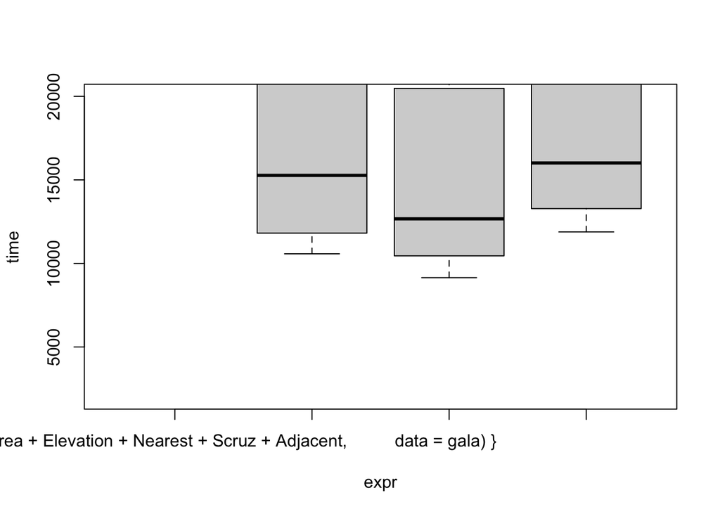

```r
#library(microbenchmark)
mean_timings <- microbenchmark(
  {
    lm(Species ~ Area + Elevation + Nearest + Scruz + Adjacent, data = gala)
  },
  {solve(crossprod(x), crossprod(x, y))},
  {solve(r, crossprod(q, y))},
  {solve(crossprod(sigma, t(v)), crossprod(u, y))},
  times = 100
)

plot(mean_timings,
     ylim=c(2000, 20000))
```

```r
# loading larger data frame
storms_clean <- na.omit(select(storms,
                               -c(name,
                                  status,
                                  tropicalstorm_force_diameter,
                                  hurricane_force_diameter,
                                  category)))
glimpse(storms_clean)
```

```
Rows: 19,537
Columns: 8
$ year     <dbl> 1975, 1975, 1975, 1975, 1975, 1975, 1975, 1975, 1975, 1975, 1…
$ month    <dbl> 6, 6, 6, 6, 6, 6, 6, 6, 6, 6, 6, 6, 6, 6, 6, 6, 7, 7, 7, 7, 7…
$ day      <int> 27, 27, 27, 27, 28, 28, 28, 28, 29, 29, 29, 29, 30, 30, 30, 3…
$ hour     <dbl> 0, 6, 12, 18, 0, 6, 12, 18, 0, 6, 12, 18, 0, 6, 12, 18, 0, 6,…
$ lat      <dbl> 27.5, 28.5, 29.5, 30.5, 31.5, 32.4, 33.3, 34.0, 34.4, 34.0, 3…
$ long     <dbl> -79.0, -79.0, -79.0, -79.0, -78.8, -78.7, -78.0, -77.0, -75.8…
$ wind     <int> 25, 25, 25, 25, 25, 25, 25, 30, 35, 40, 45, 50, 50, 55, 60, 6…
$ pressure <int> 1013, 1013, 1013, 1013, 1012, 1012, 1011, 1006, 1004, 1002, 1…
```

```r
# working with a bigger model
full_lmod <- lm(wind ~ ., data = storms_clean)
y_big <- storms$wind
x_big <- model.matrix(full_lmod)
qr_result_big <- qr(x_big)
q_big <- qr.Q(qr_result_big)
r_big <- qr.R(qr_result_big)
svd_result_big <- svd(x_big)
v_big <- svd_result_big$v
sigma_big <- diag(svd_result_big$d)
u_big <- svd_result_big$u
```

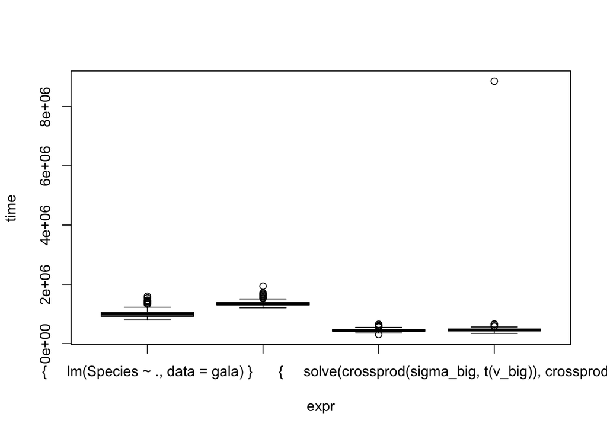

```r
mean_timings2 <- microbenchmark(
  {lm(Species ~ ., data = gala)},
  {solve(crossprod(x_big), crossprod(x_big, y_big))},
  {solve(r_big, crossprod(q_big, y_big))},
  {solve(crossprod(sigma_big, t(v_big)), crossprod(u_big, y_big))},
  times = 100
)

plot(mean_timings2)
```

```r
#     ylim=c(2000, 250000))
```

# Appendix A: A Glossary of Useful Functions

## Basics of Linear Algebra in R

Some useful commands when working with matrices in R:

- `a %*% b` computes matrix product where $a$ and $b$ denote matrices.
- `t(a)` gives the transpose of matrix $a$.
- `solve(a)` finds the inverse of matrix $a$.
- `solve(a,b)` solves the equation $ax=b$.
- `det(a)` computes determinant of square matrix $a$.
- `crossprod(x,y)` Computes the matrix cross product $x \times y = x^Ty$.
- `matrix()` can be used to define a matrix from scratch.
- `diag(n)` creates $\mathbf{I}_n$, the $n \times n$ identify matrix.

## Refresher for `lm()`

Some useful commands working with `lm`:

- `coef(lmod)` Returns only the values of the regression coefficients, $\boldsymbol{\hat{\beta}}$.
- `x <- model.matrix( ~ x1 + x2 + x3 + x4, data = data.frame)` creates matrix $X$.
- `y <- data.frame$response_var` creates vector of observed values of $\mathbf{y}$.
- `names(lmod)` Lists the quantities we can extract from the `lmod`.
- `e <- residuals(lmod)` creates the vector of residuals $\hat{\boldsymbol\epsilon}$.
- `deviance(lmod)` computes the RSS of the linear model.
- `df.residual(lmod)` computes the degrees of freedom $n-p$.
- `sigma(lmod)` computes the estimate for the standard error $\hat{\sigma}$.
- `vcov(lmod)` gives the estimated covariance matrix of the regression coefficients.

# Appendix B: Random Vectors

Let $\mathbf{y}=(Y_1,Y_2,\dots,Y_n )^T$ is a random vector if it is an $n\times1$ vector of random variables.

## Mean, Variance, and Covariance

The mean of a random vector is

$$E(\mathbf{y})=\begin{pmatrix}E(Y_1)\\E(Y_2)\\\vdots\\E(Y_n)\end{pmatrix}.$$

The variance (covariance) of a random vector is

$$\begin{align}
\mathrm{Var}(\mathbf{y}) &= E(\mathbf{y}\mathbf{y}^T )-E(\mathbf{y})E(\mathbf{y})^T\\
\\
&= \begin{pmatrix}\mathrm{Var}(Y_1) & \mathrm{Cov}(Y_1,Y_2) &\dots &\mathrm{Cov}(Y_1,Y_n)\\\mathrm{Cov}(Y_2,Y_1 )&\mathrm{Var}(Y_2)&\dots&\mathrm{Cov}(Y_2,Y_n)\\\vdots&\vdots&\vdots&\vdots\\
\mathrm{Cov}(Y_n,Y_1)&\mathrm{Cov}(Y_n,Y_2)&\dots&\mathrm{Var}(Y_n)\end{pmatrix}\end{align}.$$

Let $\mathbf{x} = (X_1, X_2, \ldots, X_n)^T$ and $\mathbf{y} = (Y_1, Y_2, \ldots, Y_n)^T$ be $n\times 1$ random vectors.

The covariance between two random vectors is
$$\mathrm{Cov}(\mathbf{x}, \mathbf{y}) = E(\mathbf{x} \mathbf{y}^T) - E(\mathbf{x}) E(\mathbf{y})^T.$$

## Properties of Transformations of Random Vectors

Define:

- $\mathbf{a}$ to be an $n\times 1$ vector of constants
- $A$ to be an $m\times n$ matrix of constants
- $\mathbf{x}=(X_1,X_2,\ldots,X_n)^T$ to be an $n\times 1$ random vector
- $\mathbf{y}=(Y_1,Y_2,\ldots,Y_n)^T$ to be an $n\times 1$ random vector
- $\mathbf{z}=(Z_1,Z_2,\ldots,Z_n)^T$ to be an $n\times 1$ random vector
- $0_{n\times n}$ to be an $n\times n$ matrix of zeros.

Then:

- $E(A\mathbf{y})=AE(\mathbf{y}), E(\mathbf{y}A^T )=E(\mathbf{y}) A^T.$
- $E(\mathbf{x}+\mathbf{y})=E(\mathbf{x})+E(\mathbf{y})$
- $\mathrm{Var}(A\mathbf{y})=A \ \mathrm{Var}(\mathbf{y}) A^T$
- $\mathrm{Cov}(\mathbf{x}+\mathbf{y},\mathbf{z})=\mathrm{Cov}(\mathbf{x},\mathbf{z})+\mathrm{Cov}(\mathbf{y},\mathbf{z})$
- $\mathrm{Cov}(\mathbf{x},\mathbf{y}+\mathbf{z})=\mathrm{Cov}(\mathbf{x},\mathbf{y})+\mathrm{Cov}(\mathbf{x},\mathbf{z})$
- $\mathrm{Cov}(A\mathbf{x},\mathbf{y})=A\ \mathrm{Cov}(\mathbf{x},\mathbf{y})$
- $\mathrm{Cov}(\mathbf{x},A\mathbf{y})=\mathrm{Cov}(\mathbf{x},\mathbf{y}) A^T$
- $\mathrm{Var}(a)= 0_{n\times n}$
- $\mathrm{Cov}(\mathbf{a},\mathbf{y})=0_{n\times n}$
- $\mathrm{Var}(\mathbf{a}+\mathbf{y})= \mathrm{Var}(\mathbf{y})$